# problem set 3

2024-04-04

# a.

```r
library('tidyverse')
```

```r
library('forcats')

movies <- read.csv("datasets/IMDB_movies.csv")

movies_clean <-
  movies %>%
  mutate(budgetM = budget/1000000,
         grossM = gross/1000000,
         profitM = grossM - budgetM,
         ROI = profitM/budgetM,
         blockbuster = ifelse(profitM > 100, 1,0) %>% factor(., levels = c("0","1")),
         blockbuster_numeric = ifelse(profitM > 100, 1,0),
         genre_main = as.factor(unlist(map(strsplit(as.character(movies$genres),"\\|"),1))) %>% fct_lump(10),
         rating_simple = fct_lump(content_rating, n = 5)
  ) %>%
  filter(country == "USA",
         content_rating != "",
         content_rating != "Not Rated",
         !is.na(gross)) %>%
  mutate(rating_simple = rating_simple %>% fct_drop()) %>%
  rename(director = director_name,
         title = movie_title,
         year = title_year) %>%
  select(-c(actor_1_name, actor_2_name,actor_1_facebook_likes, actor_2_facebook_likes,
            budget, gross, aspect_ratio, num_voted_users,num_user_for_reviews)) %>%
  relocate(title, year, country, director, budgetM, grossM, profitM, ROI, imdb_score, genre_main, rating_simple, language, duration) %>%
  distinct()
```

# b.

```r
library(rsample)

set.seed(42)
split <- initial_split(movies_clean, prop = 0.75)
train_set <- training(split)
test_set <- testing(split)
```

# c.

```r
movies_logit1 <- glm(blockbuster ~ imdb_score + budgetM + year + director_facebook_likes + genre_main,
                     data = train_set,
                     family = binomial())

summary(movies_logit1)
```

```
##
## Call:
## glm(formula = blockbuster ~ imdb_score + budgetM + year + director_facebook_likes +
##     genre_main, family = binomial(), data = train_set)
##
## Coefficients:
##                           Estimate Std. Error z value Pr(>|z|)
## (Intercept)              4.321e+01  1.795e+01   2.407  0.01608 *
## imdb_score               1.328e+00  1.334e-01   9.956  < 2e-16 ***
## budgetM                  1.181e-02  1.997e-03   5.915 3.31e-09 ***
## year                    -2.765e-02  8.889e-03  -3.111  0.00186 **
## director_facebook_likes -9.254e-06  2.193e-05  -0.422  0.67308
## genre_mainAdventure      1.334e-01  2.765e-01   0.482  0.62955
## genre_mainAnimation      1.501e-01  6.777e-01   0.222  0.82466
## genre_mainBiography     -8.656e-01  4.869e-01  -1.778  0.07545 .
## genre_mainComedy         1.758e-01  2.909e-01   0.604  0.54568
## genre_mainCrime         -1.937e+00  6.439e-01  -3.008  0.00263 **
## genre_mainDocumentary   -1.002e+00  1.080e+00  -0.927  0.35371
## genre_mainDrama         -7.771e-01  3.388e-01  -2.293  0.02183 *
## genre_mainFantasy       -1.371e+01  4.532e+02  -0.030  0.97586
## genre_mainHorror        -2.994e-01  7.808e-01  -0.383  0.70139
## genre_mainOther         -6.835e-01  1.070e+00  -0.639  0.52295
## ---
## Signif. codes:  0 '***' 0.001 '**' 0.01 '*' 0.05 '.' 0.1 ' ' 1
##
## (Dispersion parameter for binomial family taken to be 1)
##
##     Null deviance: 1100.80  on 2239  degrees of freedom
## Residual deviance:  841.05  on 2225  degrees of freedom
## AIC: 871.05
##
## Number of Fisher Scoring iterations: 15
```

# crime makes the movie less likely to be blockbuster as its coefficant is 0.14, which is below 1, so unlikely to happen

# imdb has a coefficant of of 3.77 so its not true that blockbusters get a lower score.

# Movies with high imdb scores are more likely to be blockbusters as its above 1.00.

```r
exp(coef(movies_logit1))
```

```
##             (Intercept)              imdb_score                 budgetM
##            5.803566e+18            3.772198e+00            1.011884e+00
##                    year director_facebook_likes     genre_mainAdventure
##            9.727255e-01            9.999907e-01            1.142662e+00
##     genre_mainAnimation     genre_mainBiography        genre_mainComedy
##            1.161999e+00            4.207982e-01            1.192183e+00
##         genre_mainCrime   genre_mainDocumentary         genre_mainDrama
##            1.441413e-01            3.671275e-01            4.597446e-01
##       genre_mainFantasy        genre_mainHorror         genre_mainOther
##            1.106303e-06            7.412727e-01            5.048650e-01
```

# f.

```r
train_predictions <- predict(movies_logit1, train_set, type = "response")
test_predictions <- predict(movies_logit1, test_set, type = "response")

head(train_predictions)
```

```
##            1            2            3            4            5            6
## 5.265728e-03 5.222137e-05 6.165732e-02 8.350837e-03 3.515521e-02 4.240390e-02
```

```r
head(test_predictions)
```

```
##         1         2         3         4         5         6
## 0.2658367 0.1544884 0.7850275 0.3289948 0.6213258 0.3644735
```

```r
library(ggplot2)
library(plotROC)
```

# g.

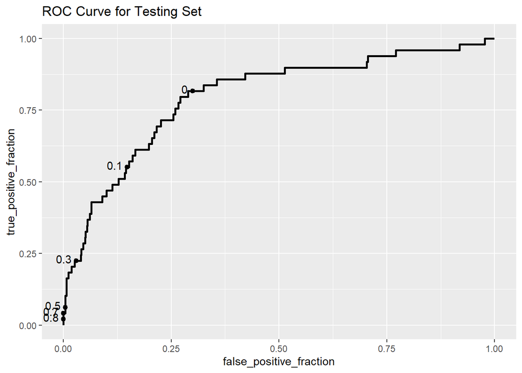

```r
# Plot for Training Set
roc_train = ggplot(train_set, aes(d = blockbuster_numeric, m = train_predictions)) + geom_roc(cutoffs.at = c(0.9,0.7,0.5,0.3,0.1,0.05)) + ggtitle("ROC Curve for Training Set")

# Plot for Test Set
roc_test = ggplot(test_set, aes(d = blockbuster_numeric, m = test_predictions)) + geom_roc(cutoffs.at = c(0.9,0.7,0.5,0.3,0.1,0.05)) + ggtitle("ROC Curve for Testing Set")

roc_test
```

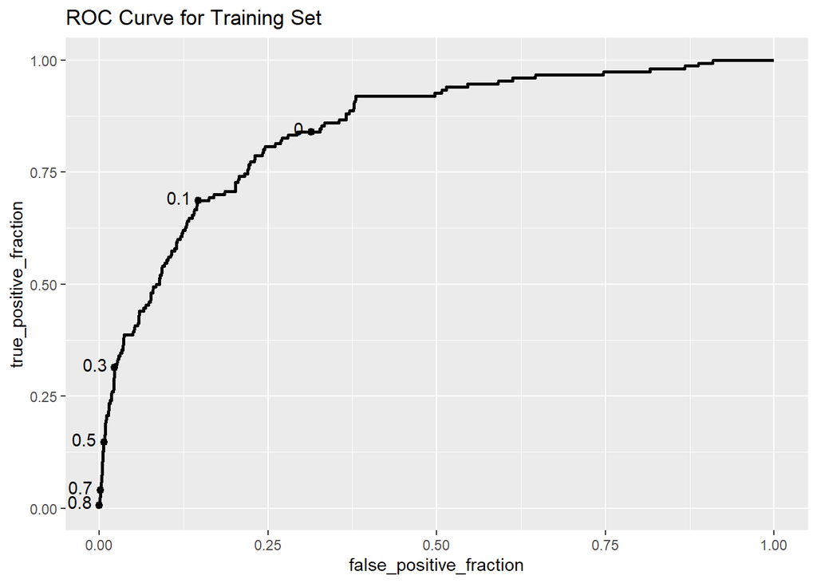

```r
roc_train
```

# h, chose cutoff of .1, that minimizes false_positive_fraction and maximizes true positive fraction.

# a smaller cutoff would result in more false positive, I picked a cutoff the maximizes true positives while minimizing false positives.

# i.

```r
cutoff = 0.1
library(yardstick)
train_classified <- ifelse(train_predictions > cutoff, 1, 0)
test_classified <- ifelse(test_predictions > cutoff, 1, 0)


results_train = data.frame(
  true = factor(train_set$blockbuster_numeric),
  pred = factor(train_classified),
  scores = train_predictions
)
results_train %>% glimpse()
```

```
## Rows: 2,240
## Columns: 3
## $ true   <fct> 0, 0, 0, 0, 0, 0, 0, 0, 0, 0, 0, 0, 0, 0, 0, 0, 0, 0, 0, 1, 0, …
## $ pred   <fct> 0, 0, 0, 0, 0, 0, 0, 0, 0, 0, 0, 0, 0, 0, 0, 0, 0, 0, 0, 0, 0, …
## $ scores <dbl> 5.265728e-03, 5.222137e-05, 6.165732e-02, 8.350837e-03, 3.51552…
```

```r
summary(results_train)
```

```
##  true     pred         scores
##  0:2090   0:1831   Min.   :0.00000
##  1: 150   1: 409   1st Qu.:0.01119
##                    Median :0.03018
##                    Mean   :0.06696
##                    3rd Qu.:0.07317
##                    Max.   :0.83313
```

```r
results_test = data.frame(
  true = factor(test_set$blockbuster_numeric),
  pred = factor(test_classified),
  scores = test_predictions
)

results_test %>% glimpse()
```

```
## Rows: 747
## Columns: 3
## $ true   <fct> 0, 0, 1, 1, 0, 0, 0, 0, 0, 1, 0, 1, 0, 0, 1, 1, 0, 0, 0, 0, 0, …
## $ pred   <fct> 1, 1, 1, 1, 1, 1, 1, 1, 1, 1, 1, 1, 1, 0, 1, 0, 1, 0, 1, 1, 1, …
## $ scores <dbl> 0.265836715, 0.154488448, 0.785027506, 0.328994771, 0.621325790…
```

# J. Confusion matrix

```r
cm_test = conf_mat(results_test,
              truth = true,
              estimate = pred)

cm_test
```

```
##           Truth
## Prediction   0   1
##          0 595  22
##          1 103  27
```

```r
cm_train = conf_mat(results_train,
                    truth = true,
                    estimate = pred)
cm_train
```

```
##           Truth
## Prediction    0    1
##          0 1784   47
##          1  306  103
```

# k.

```r
TN_train = 1784
TP_train = 103
FP_train = 306
FN_train = 47

train_acc = (TP_train + TN_train) / (TP_train + TN_train + FP_train + FN_train)
print(train_acc)
```

```
## [1] 0.8424107
```

```r
train_sen = TP_train / (TP_train + FN_train)
train_sen
```

```
## [1] 0.6866667
```

```r
train_spe = TN_train / (TN_train + FP_train)

print(train_spe)
```

```
## [1] 0.8535885
```

```r
TN = 595
TP = 27
FP = 103
FN = 22

test_acc = (TP + TN) / (TP + TN + FP + FN)
print(test_acc)
```

```
## [1] 0.832664
```

```r
test_sen = TP / (TP + FN)

test_sen
```

```
## [1] 0.5510204
```

```r
test_spe = TN / (TN + FP)

print(test_spe)
```

```
## [1] 0.8524355
```

```r
library(forcats)
```

# Given the AUC scores, the model does not appear to be severely over fitting,

# as the performance on the test set remains relatively close to the training set performance. However,

# the modest drop from training to test AUC suggests there is some over fitting happening

# if concerned about the over fitting, we could apply regularization techniques to penalize complex models and reduce overfitting.

# we could also simplify the model by removing irrelevant input features that do not contribute much to the predictive power of the model but may be contributing to noise.

```r
calc_auc(roc_train)
```

```
##   PANEL group      AUC
## 1     1    -1 0.847547
```

```r
calc_auc(roc_test)
```

```
##   PANEL group       AUC
## 1     1    -1 0.7978773
```